# 04b_analyze_section_order

Erin Becker

November 3, 2017

# Section order

Here we analyze document similarity based on the degree of shared order of sections within a document. Sections are defined in 04_define_sections.Rmd.

Our approach is based on the idea of *synteny* from the field of genomics. Two (or more) genes are said to have synteny if those genes are found in proximity across a set of genomes. The degree of synteny is proportional to the frequency with which genes are colocalized and the evolutionary distance of organisms in which that colocalization occurs.

A genome-wide *synteny index* between a pair of genomes can be defined by calculating the *synteny* for all genes shared between that genome pair and taking the average.

[Reference](http://www.tandfonline.com/doi/full/10.1080/2159256X.2015.1120576)

For this analysis, **genes** are equivalent to **sections** (not **entries**) and **genomes** are equivalent to **documents**.

### Limitations/Issues:

- SI is only defined for sections shared between two documents. If there is no overlap in sections, the genome-wide SI is 0. Short documents will tend to have extremes of SI, either 1 (all sections shared) or 0 (no sections shared). We will include only documents above a certain section-number threshold for this analysis.
- A reasonable value of `k` (neighborhood size) will need to be determined by trial and error. This may also depend on the distribution of document lengths across our corpus.
- This method was developed for microbial genomes, which are usually circular. Our documents are not circular, so we will need to decide how to treat sections that occur within `k` sections of the beginning or end of a document.
  - Idea: add a section called “top” and one called “bottom” when known to a document. Treat these as sections in the SI calculations.
- The document wide SI is the average SI for of all shared sections. Non-shared sections are not included in the calculation.
- All of our documents are broken. We usually don’t know whether a section is absent from a document because the original scribe did not include it or because it was originally included and subsequently lost due to damage. This also occurs in microbial genomes, particularly in metagenomic sequencing where incomplete genomes are assembled.
- How should we deal with sections that appear multiple times in a document? This happens in microbial genomes when genes are repeated within a genome.
- When two sections are flipped in order, this method wouldn’t notice (unless the documents are relatively long compared to k). Do we want it to?

## Read in section definitions

Sections were defined [previously](https://github.com/ErinBecker/digital-humanities-phylogenetics/blob/master/scripts/04_define_sections.Rmd) and are read in from file here.

## Read in a corpus to analyze

We now read in a csv file containing the data from all of our exemplar texts (and a few unrelated documents to act as outgroups).

There are 138 documents in our corpus, including our composite text.

### Step 1: Determine order of sections for each document in corpus

For each entry in each document in the corpus, identify which section it belongs to. Add this section identification to a new column in the dataframe. If an entry is found in more than one section, section names are separated by “:”.

```r
add_sections_to_entries = function(df, section_defs) {

  for (i in 1:nrow(df)) {
      entry = tolower(df$entry[i])
      sections = names(which(sapply(section_defs, function(x) any(x == entry)) == TRUE))
      if (length(sections) == 0) df$section[i] = NA
      else df$section[i] = paste(sections, collapse = ":")
  }
  df
}

corpus = add_sections_to_entries(corpus, Q39_sections)
```

We can preview the section definitions:

```
##    id_text                        entry section
## 1  P117395                  ŋešed[key]N    <NA>
## 2  P117395                pakud[~tree]N    <NA>
## 3  P117395                 raba[clamp]N    <NA>
## 4  P117404       ig[door]N_eren[cedar]N    <NA>
## 5  P117404        ig[door]N_dib[board]N    door
## 6  P117404            ig[door]N_i[oil]N    door
## 7  P128345     garig[comb]N_siki[hair]N    comb
## 8  P128345 garig[comb]N_siki-siki[NA]NA    <NA>
## 9  P128345    garig[comb]N_saŋdu[head]N    comb
## 10 P224980              gigir[chariot]N chariot
```

Many entries will not be assigned to a section because they either do not appear verbatium in the Q text that was used to define sections or they do appear in the Q text, but were not part of a section (i.e. they were not adjacent to another entry that shared enough similarity to be considered part of the same section).

We then check how common it was for entries to be assigned to more than one section.

```r
unique(corpus[grep(":", corpus$section),]$entry)
```

```
## [1] "ŋešgana[pestle]N"
```

Only the entry “ŋešgana[pestle]N” appears in two sections in the Q39 corpus. This entry appears in several documents.

```r
unique(corpus[grep(":", corpus$section),])
```

```
##      id_text id_line    label            lemma       base skip
## 563  P247864     280   o v 28 ŋešgana[pestle]N ŋeš-gan-na    0
## 2052 P271301     352  r ii 36 ŋešgana[pestle]N ŋeš-gan-na    0
## 3329 P273880     293 b iii 17 ŋešgana[pestle]N ŋeš-gan-na    0
## 3794 P312012       3        3 ŋešgana[pestle]N ŋeš-gan-na    0
## 5559 P429503     121 r i' 25' ŋešgana[pestle]N ŋeš-gan-na    0
## 7369 Q000039     172     145a ŋešgana[pestle]N   ŋeš-gana    0
## 7493 Q000039     296      260 ŋešgana[pestle]N ŋeš-gan-na    0
##                 entry     section
## 563  ŋešgana[pestle]N tool:mortar
## 2052 ŋešgana[pestle]N tool:mortar
## 3329 ŋešgana[pestle]N tool:mortar
## 3794 ŋešgana[pestle]N tool:mortar
## 5559 ŋešgana[pestle]N tool:mortar
## 7369 ŋešgana[pestle]N tool:mortar
## 7493 ŋešgana[pestle]N tool:mortar
```

Now that we know which section(s) each entry belongs to, we can define the order of sections for each document.First, we split our dataframe by id_text so that each document is in its own dataframe. We then have a list of dataframes. We then extract the “section” column from each of those dataframes. This gives us a list of character vectors.

```
## $P117395
## [1] NA NA NA
##
## $P117404
## [1] NA     "door" "door"
##
## $P128345
## [1] "comb" NA     "comb"
##
## $P224980
## [1] "chariot" "chariot" "chariot"
##
## $P224986
## [1] "chair" "chair" NA
##
## $P224994
## [1] NA NA NA
```

We need to get rid of `NA`s. These represent entries that were not assigned to a section. Then we retain only documents that are not of length zero (i.e. documents that had at least one entry assigned to a section).

```
## $P117404
## [1] "door" "door"
##
## $P128345
## [1] "comb" "comb"
##
## $P224980
## [1] "chariot" "chariot" "chariot"
##
## $P224986
## [1] "chair" "chair"
##
## $P224996
## [1] "chair" "chair" "chair"
##
## $P225006
## [1] "door" "door"
```

This leaves us with 123 documents in our corpus.

We can then use the `rle()` function (“run length encoding”) to get a character vector of the sections in each document, in order. This function calculates the lengths and values of runs in a sequence. We’re not interested in the lengths of the runs (for this analysis), but can extract the values (names of sections). We end up with a list of character vectors.

```
## $P117404
## [1] "door"
##
## $P128345
## [1] "comb"
##
## $P224980
## [1] "chariot"
##
## $P224986
## [1] "chair"
##
## $P224996
## [1] "chair"
##
## $P225006
## [1] "door"
```

We will focus our analysis on documents with eight or more sections.

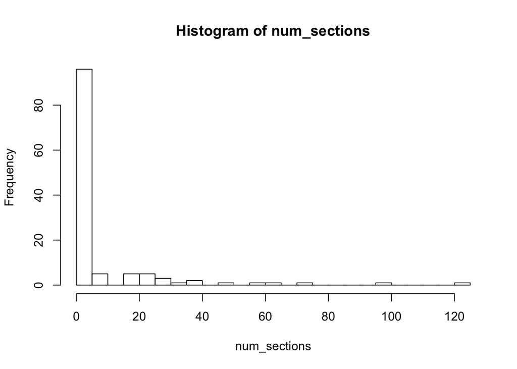

```r
num_sections = sapply(doc_sections, length)
hist(num_sections, breaks = 20)
```

```r
doc_sections_keep = doc_sections[which(num_sections >= 8)]
```

There are 24 documents remaining in our corpus.

### Method 1: Repeated sections combined

One important consideration in calculating section order is in determining how to count sections that appear multiple times within a document. For this method, we consider repeated sections as a single section and combine their k-neighborhoods.

We first define function to get the section neighborhood for any given section in any given document. This function must be agnostic to the number of times a section appears in a document, combining the neighborhoods for all times that section appears. Individual neighborhoods are **neighborhood**, combined neighborhoods are **n**.

Note also that the complicated indexing within the for loop is required to avoid going out of bounds. This is important for the first few and last few sections in a document. Going out of bounds into negative numbers will throw a `Traceback error`, however, going out of bounds into numbers larger than the length of the vector you’re indexing will add `NA`s to your resulting vector. This is worse because the `NA` is counted as an item in the intersection!

Another thing to notice is that the grep statement only finds whole word matches. This is accomplished by using the “beginning of string” `^` and “end of string” `$` metacharacters within the regular expression search.

```r
get_neighborhood = function(doc, i, k) {

    # create vector to store combined neighborhoods
    n = c()

    # search for a section within a document and extract neighborhood
    for(x in grep(paste0("^",i,"$"), doc)) {

        if(x >= k+1 & x <= length(doc) - k) sequence = (x - k):(x + k)
        else if(x < k+1) sequence = 1:(x + k)
        else if(x > length(doc) - k) sequence = (x - k):length(doc)

        neighborhood = doc[sequence]

        # add neighborhood to combined neighborhoods for repeated sections
        n = c(n, neighborhood)
        #print(paste("The combined neighborhood is:", n))
}
        # return combined neighborhood
        n
}
```

Next we create a dataframe to store our results. It will have the following columns:

- `doc_A` = text_id for first document in compared pair
- `doc_B` = text_id for second document in compared pair
- `num_shared_sec` = length(I) or number of shared sections between the two documents
- `SI` = document wide SI

The function `combn` allows us to get all possible combinations of documents. `t` transposes the resulting data.frame.

```
## [1] 0
```

```
## [1] doc_A          doc_B          num_shared_sec SI
## [5] k
## <0 rows> (or 0-length row.names)
```

```
## [1] doc_A          doc_B          num_shared_sec SI
## [5] k
## <0 rows> (or 0-length row.names)
```

Now we use the `calc_SI` function to iterate through each of the document pairs and store the results in our data.frame `all_pairs_SI`.

The maximum possible SI for a pair of document should be 2*k. However, there are a few complications.

1. Our documents are not circular. Therefore, the first k and last k sections in a document can not have 2*k neighbors. This reduces the maximum possible SI for a given document pair and makes the actual maximum SI possible dependent on document length.
2. Because some sections are repeated more than once in a document (particularly “garbage” sections like X.6), and this method pools the neighborhoods for all times a section appears in a document, the maximum calculated SI can be greater than 2*k. In fact, the maximum calculated SI can be arbitraribly large, if many sections are repeated within a document.

# Visually inspect that all cases of SI > 2k are identical docs.

# change all SI > 2k to 2k

all_pairs_SI[which(all_pairs_SI$SI > 2*k),]$SI = 2*k

We also have many document pairs with an SI of NaN. These appear to be cases where two documents have no shared sections (and therefore SI was calculated as 0/0). The following checks that this is the case for all instances of SI = NaN and sets the SI for these document pairs to be -2k.

# check that all doc pairs with SI of NaN have zero shared sections

unique(all_pairs_SI[which(is.na(all_pairs_SI$SI)),]$num_shared_sec)

# if this condition is true provisionally replace SI of NaN to -2k

# so that distance will be greatest for these doc pairs

# Calculate distance and add to dataframe

# Extract the columns of the data frame we need to build a dendrogram

# round the distances

all_pairs_SI$dist = round(all_pairs_SI$dist, 2)

### Create bootstrapped corpuses

We now create many different versions of the input corpus by resampling from within the corpus file (QXX_par). This will enable us to evaluate the quality of each branching point on our dendrograms based on the fraction of dendrograms generated from these bootstrapped corpuses that replicate that branching point. Note that eval is set to FALSE so that these don’t regenerate every time the file is knit.

#### Note to self:

Need to make sure the boostrapped corpuses are sorted before analyzing whether sequential entries are in the same section (or check to see if the algorithm checks for row number).

```r
Q39_par = read.csv("~/Box Sync/digital-humanities-phylogenetics/data/pass/Q39_par.csv", stringsAsFactors = FALSE)

for(i in 1:1000) {
  filename = paste0("~/Box Sync/digital-humanities-phylogenetics/data/pass/bootstrap/Q39_par_bootstrap/Q39_par_bootstrap_", i, ".csv")
  rows = sample(1:nrow(Q39_par), replace = TRUE)
  corpus_bootstrap = Q39_par[rows,]
  write.csv(corpus_bootstrap, filename, row.names = FALSE)
}
```